# Ecommerce Website Seasonality & Customer behavior Analysis

# Table of Contents

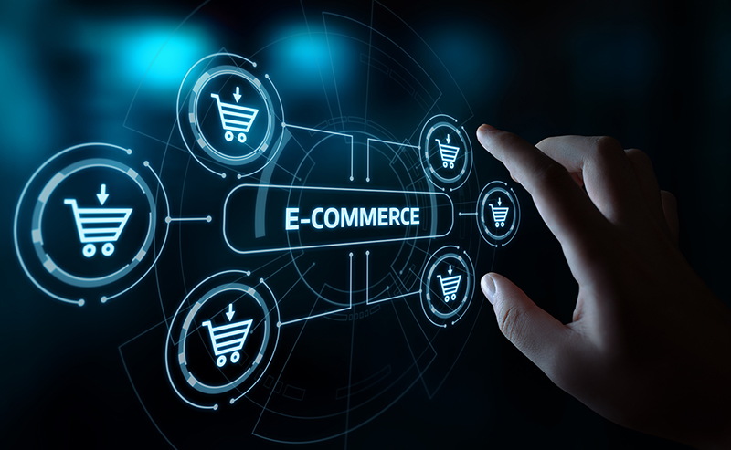

### Introduction

**we will be Analysing and studying a US Ecommerce website dataset to come up with a future plan to implement and maximize revenue along with managing customer churn. machine learning models, NLP, time series would be used or any other tool/ library that we would see fit to use in this exploration.**

**Description of the data:**

The dataset contains the transaction history of an online store that sells household goods.

The file `ecommerce_dataset_us.csv` contains the following columns:

`InvoiceNo` — order identifier

`StockCode` — item identifier

`Description` — item name

`Quantity`

`InvoiceDate` — order date

`UnitPrice` — price per item

`CustomerID`

## Data Loading and Pre-Processing

```python
#import libraries

import pandas as pd
import numpy as np
import datetime
import re

#visuallizations
%matplotlib inline
import matplotlib.pyplot as plt
import seaborn as sns

#NLP - Natural Language Processing
import nltk
from nltk.tokenize import word_tokenize
from collections import Counter
from nltk.stem import WordNetLemmatizer
from nltk.corpus import stopwords

'''#import if needed
nltk.download('stopwords')
nltk.download('wordnet')
nltk.download('omw-1.4')
nltk.download('punkt')'''


# Kmeans segmentation
from sklearn.cluster import KMeans
from sklearn.preprocessing import StandardScaler

# Association Rule model

# ! pip install mlxtend
from mlxtend.frequent_patterns import apriori, association_rules
```

```python
# set a dataframe and read few rows
df = pd.read_csv('ecommerce_dataset_us.csv', on_bad_lines='skip', sep= '\t')
df.head()
```

|  | InvoiceNo | StockCode | Description | Quantity | InvoiceDate | UnitPrice | CustomerID |
| --- | --- | --- | --- | --- | --- | --- | --- |
| 0 | 536365 | 85123A | WHITE HANGING HEART T-LIGHT HOLDER | 6 | 11/29/2018 08:26 | 2.55 | 17850.0 |
| 1 | 536365 | 71053 | WHITE METAL LANTERN | 6 | 11/29/2018 08:26 | 3.39 | 17850.0 |
| 2 | 536365 | 84406B | CREAM CUPID HEARTS COAT HANGER | 8 | 11/29/2018 08:26 | 2.75 | 17850.0 |
| 3 | 536365 | 84029G | KNITTED UNION FLAG HOT WATER BOTTLE | 6 | 11/29/2018 08:26 | 3.39 | 17850.0 |
| 4 | 536365 | 84029E | RED WOOLLY HOTTIE WHITE HEART. | 6 | 11/29/2018 08:26 | 3.39 | 17850.0 |

```python
#get info
df.info()
```

```
<class 'pandas.core.frame.DataFrame'>
RangeIndex: 541909 entries, 0 to 541908
Data columns (total 7 columns):
 #   Column       Non-Null Count   Dtype
---  ------       --------------   -----
 0   InvoiceNo    541909 non-null  object
 1   StockCode    541909 non-null  object
 2   Description  540455 non-null  object
 3   Quantity     541909 non-null  int64
 4   InvoiceDate  541909 non-null  object
 5   UnitPrice    541909 non-null  float64
 6   CustomerID   406829 non-null  float64
dtypes: float64(2), int64(1), object(4)
memory usage: 28.9+ MB
```

```python
# data quantitive describtion
df.describe()
```

|  | Quantity | UnitPrice | CustomerID |
| --- | --- | --- | --- |
| count | 541909.000000 | 541909.000000 | 406829.000000 |
| mean | 9.552250 | 4.611114 | 15287.690570 |
| std | 218.081158 | 96.759853 | 1713.600303 |
| min | -80995.000000 | -11062.060000 | 12346.000000 |
| 25% | 1.000000 | 1.250000 | 13953.000000 |
| 50% | 3.000000 | 2.080000 | 15152.000000 |
| 75% | 10.000000 | 4.130000 | 16791.000000 |
| max | 80995.000000 | 38970.000000 | 18287.000000 |

```python
# any duplicates ?
df.duplicated().sum()
```

```
5268
```

```python
#check missing values
df.isnull().sum()
```

```
InvoiceNo           0
StockCode           0
Description      1454
Quantity            0
InvoiceDate         0
UnitPrice           0
CustomerID     135080
dtype: int64
```

### Data Loading and Pre-Processing Overview

- the Data has 541909 entries in 7 columns
- there are missing values in `CustomerID` - `Description`
- Wrong column datatype `InvoiceDate` - `CustomerID`
- `Quantity` and `UnitPrice` contains negative values
- 5268 duplicdated values

## Data Pre-Processing

```python
# changing Date columm Dtype

# set Datetime column
df['InvoiceDate'] = pd.to_datetime(df['InvoiceDate'])

# Datetime new columns
# df['year'] = df['invoicedate'].dt.year **if needed
df['month'] = df['InvoiceDate'].dt.month
df['day'] = df['InvoiceDate'].dt.day
df['hour'] = df['InvoiceDate'].dt.hour

# create new Total column: Quantity * Unit Price
df['Total']= df['Quantity'] * df['UnitPrice']

# check new columns
df.head(2)
```

|  | InvoiceNo | StockCode | Description | Quantity | InvoiceDate | UnitPrice | CustomerID | month | day | hour | Total |
| --- | --- | --- | --- | --- | --- | --- | --- | --- | --- | --- | --- |
| 0 | 536365 | 85123A | WHITE HANGING HEART T-LIGHT HOLDER | 6 | 2018-11-29 08:26:00 | 2.55 | 17850.0 | 11 | 29 | 8 | 15.30 |
| 1 | 536365 | 71053 | WHITE METAL LANTERN | 6 | 2018-11-29 08:26:00 | 3.39 | 17850.0 | 11 | 29 | 8 | 20.34 |

### Duplicates

```python
# duplicated data ratio in%
(df.duplicated().sum()/len(df)*100).round(2)
```

```
0.97
```

**5268 duplicates are less than 1% of dataset (0,97%), we drop them.**

```python
# drop duplicates and check
df = df.drop_duplicates().reset_index(drop=True)
df.duplicated().sum()
```

```
0
```

### Create new Dataframes

```python
# create dataframe with all negative values
df_negative = df.query(" Total <0 ")

#create a dataframe with all zero total values
df_zero = df.query('Total == 0 ')
```

```python
# make a copy of the main dataframe
df_main = df.copy()

#creat new data frame with positive values
df = df.query("Total> 0 ")

# check the new data has no negative values
len(df.query("Total<  0 "))
```

```
0
```

**as our main exploration will be on positive values, we devided the data into + and - Total values**

### Missing values

```python
# cleaned df missing description
df['Description'].isnull().sum()
```

```
0
```

```python
# negative df missing description
df_negative['Description'].isnull().sum()
```

```
0
```

```python
# zero df missing description
df_zero['Description'].isnull().sum()
```

```
1454
```

**all missing Descriptions are in Zero Total dataframe, we will leave them there in the df_zero, total zero could possibly be sort of a discout for customers**

```python
# customerID missing data in new positive dataframe
df['CustomerID'].isnull().sum()
```

```
132186
```

```python
# customerID missing data in negative dataframe
df_negative['CustomerID'].isnull().sum()
```

```
381
```

```python
# customerID missing data in Zero dataframe
df_zero['CustomerID'].isnull().sum()
```

```
2470
```

```python
# fill missing CustomerID values with Guest - all 3 dataframes
df['CustomerID'].fillna('Guest', inplace=True)
df_negative['CustomerID'].fillna('Guest', inplace=True)
df_zero['CustomerID'].fillna('Guest', inplace=True)
```

```python
# check df
df['CustomerID'].isnull().sum()
```

```
0
```

```python
# pct of the Guest (no ID Customers) from total Customers in the new POSITIVE dataframe
(df['CustomerID'].value_counts().values[0] / df['CustomerID'].value_counts().values[:].sum() *100).round(2)
```

```
25.18
```

```python
# set CustomerID as String, remove 0
df['CustomerID'] = df['CustomerID'].astype('str').str.strip('.0')
```

### Outliers

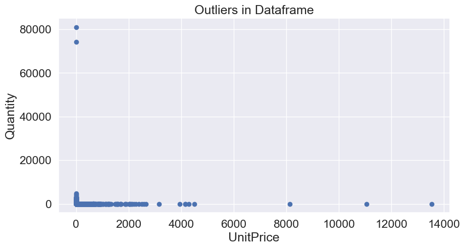

```python
plt.figure(figsize=(10, 5))
sns.set(font_scale = 1.5)
plt.scatter(x = 'UnitPrice' ,y = 'Quantity' , data = df )
plt.xlabel('UnitPrice')
plt.ylabel('Quantity')
plt.title('Outliers in Dataframe');
```

**plotting the data showed us some outliers, we will remove them for a more realistic exploration**

```python
# removing outlaiers based on the plot
df = df.query(" Quantity < 70000 & UnitPrice < 6000 ")
```

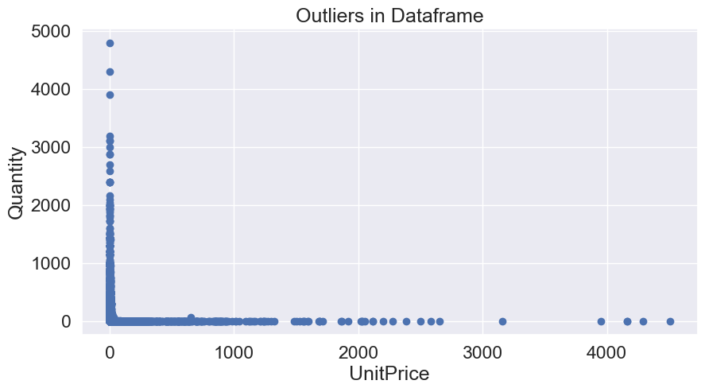

```python
# plotting again after removing outlires
plt.figure(figsize=(10, 5))
sns.set(font_scale = 1.5)
plt.scatter(x = 'UnitPrice' ,y = 'Quantity' , data = df )
plt.xlabel('UnitPrice')
plt.ylabel('Quantity')
plt.title('Outliers in Dataframe');
```

**the Data now looks better with removed outliersa for further exploration**

### Cancelled orders

```python
# get cancelled orders and their corresponding original invoices
df_pairs = df_main.groupby([df_main.CustomerID, df_main.StockCode, df_main.Quantity.abs()])\
.filter(lambda x: (len(x.Quantity.abs()) % 2 == 0) and (x.Quantity.sum() == 0))
```

```python
#check first rows of bought then cancelled orders  pairs
df_pairs.sort_values(by=['CustomerID', 'StockCode']).head()
```

|  | InvoiceNo | StockCode | Description | Quantity | InvoiceDate | UnitPrice | CustomerID | month | day | hour | Total |
| --- | --- | --- | --- | --- | --- | --- | --- | --- | --- | --- | --- |
| 61006 | 541431 | 23166 | MEDIUM CERAMIC TOP STORAGE JAR | 74215 | 2019-01-16 10:01:00 | 1.04 | 12346.0 | 1 | 16 | 10 | 77183.60 |
| 61011 | C541433 | 23166 | MEDIUM CERAMIC TOP STORAGE JAR | -74215 | 2019-01-16 10:17:00 | 1.04 | 12346.0 | 1 | 16 | 10 | -77183.60 |
| 105417 | C545329 | M | Manual | -1 | 2019-02-27 15:47:00 | 280.05 | 12352.0 | 2 | 27 | 15 | -280.05 |
| 105418 | C545329 | M | Manual | -1 | 2019-02-27 15:47:00 | 183.75 | 12352.0 | 2 | 27 | 15 | -183.75 |
| 105420 | C545330 | M | Manual | -1 | 2019-02-27 15:49:00 | 376.50 | 12352.0 | 2 | 27 | 15 | -376.50 |

```python
# remove cancellation from the positive dataframe

''' cancelled orders cant be counted in revenue'''

df = df[~df['InvoiceNo'].isin(df_pairs['InvoiceNo'])]

# pct of Cancelled and returned Invoices
print( 'pct of cancelled orders from total orders is',round((len(df_pairs)/2) / len(df_main)*100,2)\
      ,'% from positive df')
```

```
pct of cancelled orders from total orders is 0.38 % from positive df
```

### Final Checks

```python
# change columns order for a better readability
df = df[['CustomerID','InvoiceNo','StockCode','Description','InvoiceDate',\
         'month','day','hour','UnitPrice','Quantity', 'Total']]
df.head()
```

|  | CustomerID | InvoiceNo | StockCode | Description | InvoiceDate | month | day | hour | UnitPrice | Quantity | Total |
| --- | --- | --- | --- | --- | --- | --- | --- | --- | --- | --- | --- |
| 0 | 1785 | 536365 | 85123A | WHITE HANGING HEART T-LIGHT HOLDER | 2018-11-29 08:26:00 | 11 | 29 | 8 | 2.55 | 6 | 15.30 |
| 1 | 1785 | 536365 | 71053 | WHITE METAL LANTERN | 2018-11-29 08:26:00 | 11 | 29 | 8 | 3.39 | 6 | 20.34 |
| 2 | 1785 | 536365 | 84406B | CREAM CUPID HEARTS COAT HANGER | 2018-11-29 08:26:00 | 11 | 29 | 8 | 2.75 | 8 | 22.00 |
| 3 | 1785 | 536365 | 84029G | KNITTED UNION FLAG HOT WATER BOTTLE | 2018-11-29 08:26:00 | 11 | 29 | 8 | 3.39 | 6 | 20.34 |
| 4 | 1785 | 536365 | 84029E | RED WOOLLY HOTTIE WHITE HEART. | 2018-11-29 08:26:00 | 11 | 29 | 8 | 3.39 | 6 | 20.34 |

```python
# check all final data if currect
df.info()
```

```
<class 'pandas.core.frame.DataFrame'>
Int64Index: 491691 entries, 0 to 536640
Data columns (total 11 columns):
 #   Column       Non-Null Count   Dtype
---  ------       --------------   -----
 0   CustomerID   491691 non-null  object
 1   InvoiceNo    491691 non-null  object
 2   StockCode    491691 non-null  object
 3   Description  491691 non-null  object
 4   InvoiceDate  491691 non-null  datetime64[ns]
 5   month        491691 non-null  int64
 6   day          491691 non-null  int64
 7   hour         491691 non-null  int64
 8   UnitPrice    491691 non-null  float64
 9   Quantity     491691 non-null  int64
 10  Total        491691 non-null  float64
dtypes: datetime64[ns](1), float64(2), int64(4), object(4)
memory usage: 45.0+ MB
```

```python
# month and day colums should be objects not int*
```

```python
# final dataframe ratio from the main dataframe
round((len(df)/len(df_main)*100),2)
```

```
91.62
```

```python
# check customer and Invoice count
Costumer_unique = df['CustomerID'].nunique()
Invoice_unique = df['InvoiceNo'].nunique()
print( f'there are {Costumer_unique} Unique Cusotmers with a total of {Invoice_unique} Invoices')
```

```
there are 4253 Unique Cusotmers with a total of 18868 Invoices
```

### Data Pre-Processing - Conclusion

**keep in mind our main foucos is the Positive cleaned data stored as 'df'**

- 5268 duplicates removed, less than 1% of the dataset (0,97%)
- primary data was divided into a negative, zero, and positive total values
- missing values of description were only in zero data frame, were left there.
- missing values or Nan Customers were registered as Guest customers - not Registered customers
- obvious and plot-intuitive outliers were removed
- invoices of canceled orders dropped from the main positive data frame ( less than 1% of primary dataset )
- there are 4253 Unique customers with a total of 18868 Invoices
- the final positive value data frame is 91.6% of original

## Customer Segmentation

### RFM Recency, Frequency, Monetary Value of Customers

```python
#hypothetical snapshot_day data as if were doing analysis recently
snapshot_date = max(df['InvoiceDate']) + datetime.timedelta(days=1)

# Aggregate data on a customer level
rfm = df.groupby(['CustomerID']).agg({'InvoiceDate': lambda x: (snapshot_date - x.max()).days,\
                                               'InvoiceNo': 'count','Total': 'sum'})
# Rename columns for easier interpretation
rfm.rename(columns = {'InvoiceDate': 'Recency','InvoiceNo': 'Frequency',\
                           'Total': 'MonetaryValue'},inplace=True)

''' Recency - Days since last purchase
    Frequency - count of total invoices
    MonetaryValue - total amout spet
'''

# Check the first rows
rfm.head()
```

| CustomerID | Recency | Frequency | MonetaryValue |
| --- | --- | --- | --- |
| 12347 | 2 | 182 | 4310.00 |
| 12348 | 75 | 31 | 1797.24 |
| 12349 | 19 | 73 | 1757.55 |
| 1235 | 310 | 17 | 334.40 |
| 12352 | 36 | 82 | 1665.74 |

```python
#Recency Frequency and Monetary quartiles

#Recency quartiles - set range() in negative 1,longer days have lower value,set 4 as best and most Recent
r_labels = range(4, 0, -1)
r_quartiles = pd.qcut(rfm['Recency'], 4, labels = r_labels)
rfm = rfm.assign(R = r_quartiles.values)

#labling segments from 1-4,  4th segment is the highest value
labels = range(1,5)

#frequency quartiles
f_quartiles = pd.qcut(rfm['Frequency'], 4, labels = labels)
rfm = rfm.assign(F = f_quartiles.values)

#Monetray quartiles
m_quartiles = pd.qcut(rfm['MonetaryValue'], 4, labels = labels)
rfm = rfm.assign(M = m_quartiles.values)

#Check the first rows
rfm.head()
```

| CustomerID | Recency | Frequency | MonetaryValue | R | F | M |
| --- | --- | --- | --- | --- | --- | --- |
| 12347 | 2 | 182 | 4310.00 | 4 | 4 | 4 |
| 12348 | 75 | 31 | 1797.24 | 2 | 2 | 4 |
| 12349 | 19 | 73 | 1757.55 | 3 | 3 | 4 |
| 1235 | 310 | 17 | 334.40 | 1 | 2 | 2 |
| 12352 | 36 | 82 | 1665.74 | 3 | 3 | 4 |

```python
# Build RFM segment with RFM score
def join_rfm(x): return str(x['R']) + str(x['F']) + str(x['M'])
rfm['RFM_Segment'] = rfm.apply(join_rfm, axis=1)
rfm['RFM_Segment'] = rfm.apply(join_rfm, axis=1 ) # run twice to insure string clean outcome*
rfm['RFM_Score'] = rfm[['R','F','M']].sum(axis=1)
rfm.head()
```

| CustomerID | Recency | Frequency | MonetaryValue | R | F | M | RFM_Segment | RFM_Score |
| --- | --- | --- | --- | --- | --- | --- | --- | --- |
| 12347 | 2 | 182 | 4310.00 | 4 | 4 | 4 | 444 | 12 |
| 12348 | 75 | 31 | 1797.24 | 2 | 2 | 4 | 224 | 8 |
| 12349 | 19 | 73 | 1757.55 | 3 | 3 | 4 | 334 | 10 |
| 1235 | 310 | 17 | 334.40 | 1 | 2 | 2 | 122 | 5 |
| 12352 | 36 | 82 | 1665.74 | 3 | 3 | 4 | 334 | 10 |

```python
#Largest RFM segments
rfm.groupby('RFM_Segment').size().sort_values(ascending=False)[:10]
```

```
RFM_Segment
444    426
111    368
344    213
122    193
211    173
233    169
222    154
433    152
333    152
322    122
dtype: int64
```

```python
# Customers devided into segments

'''Use RFM score to group customers into Diamond, Platinum, Gold,Silver rand Bronze segments'''

def segment_me(df):
    if df['RFM_Score'] >= 11:
        return '1.Diamond'
    elif (df['RFM_Score'] >= 9) and (df['RFM_Score'] < 11) :
        return '2.Platinum'
    elif (df['RFM_Score'] >= 7) and (df['RFM_Score'] < 9) :
        return '3.Gold'
    elif (df['RFM_Score'] >= 5) and (df['RFM_Score'] < 7):
        return '4.Silver'
    else:
        return'5.Bronze'

# create new segment column and apply segmentation on data
rfm['General_Segment'] = rfm.apply(segment_me, axis=1)

#check the data with the Average values of each column
rfm.groupby('General_Segment').agg({'Recency': 'mean',\
                                         'Frequency': 'mean','MonetaryValue': ['mean', 'count']}).round(1)
```

| General_Segment | Recency mean | Frequency mean | MonetaryValue mean | MonetaryValue count |
| --- | --- | --- | --- | --- |
| 1.Diamond | 13.8 | 425.2 | 8559.3 | 813 |
| 2.Platinum | 39.5 | 90.7 | 1628.8 | 829 |
| 3.Gold | 71.4 | 44.9 | 835.2 | 905 |
| 4.Silver | 127.3 | 23.3 | 490.1 | 957 |
| 5.Bronze | 219.2 | 10.6 | 192.3 | 749 |

```python
# check rfm  dataframe
rfm.head()
```

| CustomerID | Recency | Frequency | MonetaryValue | R | F | M | RFM_Segment | RFM_Score | General_Segment |
| --- | --- | --- | --- | --- | --- | --- | --- | --- | --- |
| 12347 | 2 | 182 | 4310.00 | 4 | 4 | 4 | 444 | 12 | 1.Diamond |
| 12348 | 75 | 31 | 1797.24 | 2 | 2 | 4 | 224 | 8 | 3.Gold |
| 12349 | 19 | 73 | 1757.55 | 3 | 3 | 4 | 334 | 10 | 2.Platinum |
| 1235 | 310 | 17 | 334.40 | 1 | 2 | 2 | 122 | 5 | 4.Silver |
| 12352 | 36 | 82 | 1665.74 | 3 | 3 | 4 | 334 | 10 | 2.Platinum |

```python
#merge RFM data to main dataframe and check first rows
df = df.merge( rfm , how= 'left', on = ('CustomerID'))
pd.set_option('display.max_columns', None)
df.head()
```

|  | CustomerID | InvoiceNo | StockCode | Description | InvoiceDate | month | day | hour | UnitPrice | Quantity | Total | Recency | Frequency | MonetaryValue | R | F | M | RFM_Segment | RFM_Score | General_Segment |
| --- | --- | --- | --- | --- | --- | --- | --- | --- | --- | --- | --- | --- | --- | --- | --- | --- | --- | --- | --- | --- |
| 0 | 1785 | 536365 | 85123A | WHITE HANGING HEART T-LIGHT HOLDER | 2018-11-29 08:26:00 | 11 | 29 | 8 | 2.55 | 6 | 15.30 | 372 | 279 | 5014.85 | 1 | 4 | 4 | 144 | 9 | 2.Platinum |
| 1 | 1785 | 536365 | 71053 | WHITE METAL LANTERN | 2018-11-29 08:26:00 | 11 | 29 | 8 | 3.39 | 6 | 20.34 | 372 | 279 | 5014.85 | 1 | 4 | 4 | 144 | 9 | 2.Platinum |
| 2 | 1785 | 536365 | 84406B | CREAM CUPID HEARTS COAT HANGER | 2018-11-29 08:26:00 | 11 | 29 | 8 | 2.75 | 8 | 22.00 | 372 | 279 | 5014.85 | 1 | 4 | 4 | 144 | 9 | 2.Platinum |
| 3 | 1785 | 536365 | 84029G | KNITTED UNION FLAG HOT WATER BOTTLE | 2018-11-29 08:26:00 | 11 | 29 | 8 | 3.39 | 6 | 20.34 | 372 | 279 | 5014.85 | 1 | 4 | 4 | 144 | 9 | 2.Platinum |
| 4 | 1785 | 536365 | 84029E | RED WOOLLY HOTTIE WHITE HEART. | 2018-11-29 08:26:00 | 11 | 29 | 8 | 3.39 | 6 | 20.34 | 372 | 279 | 5014.85 | 1 | 4 | 4 | 144 | 9 | 2.Platinum |

```python
# check new data info
df.info()
```

```
<class 'pandas.core.frame.DataFrame'>
Int64Index: 491691 entries, 0 to 491690
Data columns (total 20 columns):
 #   Column           Non-Null Count   Dtype
---  ------           --------------   -----
 0   CustomerID       491691 non-null  object
 1   InvoiceNo        491691 non-null  object
 2   StockCode        491691 non-null  object
 3   Description      491691 non-null  object
 4   InvoiceDate      491691 non-null  datetime64[ns]
 5   month            491691 non-null  int64
 6   day              491691 non-null  int64
 7   hour             491691 non-null  int64
 8   UnitPrice        491691 non-null  float64
 9   Quantity         491691 non-null  int64
 10  Total            491691 non-null  float64
 11  Recency          491691 non-null  int64
 12  Frequency        491691 non-null  int64
 13  MonetaryValue    491691 non-null  float64
 14  R                491691 non-null  category
 15  F                491691 non-null  category
 16  M                491691 non-null  category
 17  RFM_Segment      491691 non-null  object
 18  RFM_Score        491691 non-null  int64
 19  General_Segment  491691 non-null  object
dtypes: category(3), datetime64[ns](1), float64(3), int64(7), object(6)
memory usage: 68.9+ MB
```

### Kmeans

**Customers Segmentation with Kmeans Clustering**

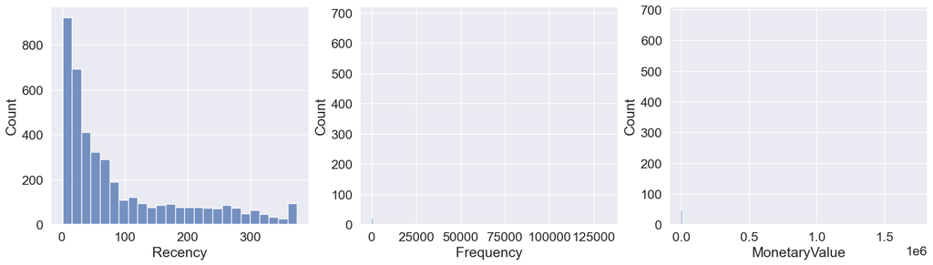

```python
''' Kmeans model and Data preparation'''

#checking the distribution of the data, unswek if needed
plt.figure(figsize = [20,5])
plt.subplot(1,3,1)
sns.histplot(rfm['Recency'])
plt.subplot(1,3,2)
sns.histplot(rfm['Frequency'])
plt.subplot(1,3,3)
sns.histplot(rfm['MonetaryValue'])
plt.show();
```

```python
# creatre new data frame only for 'Recency','Frequency','MonetaryValue' to work with Kmeans
data_rfm = rfm[['Recency','Frequency','MonetaryValue']]

# data exponentiation using numpy log
data_rfm_log = np.log(data_rfm)

# Automatic Scale of the data and fit
scaler = StandardScaler()
scaler.fit(data_rfm_log)

# Scale and center the data
data_normalized = scaler.transform(data_rfm_log)

# Create a pandas DataFrame - store for clustering
data_normalized = pd.DataFrame(data_normalized, index=data_rfm.index, columns=data_rfm.columns)

# check mean and std if scaled
print('mean: ', data_normalized.mean(axis=0).round(2))
print('std: ', data_normalized.std(axis=0).round(2))
```

```
mean:  Recency         -0.0
Frequency       -0.0
MonetaryValue   -0.0
dtype: float64
std:  Recency          1.0
Frequency        1.0
MonetaryValue    1.0
dtype: float64
```

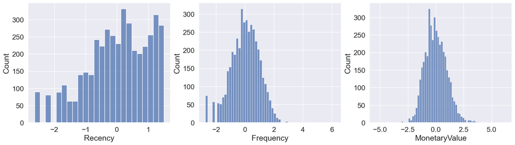

```python
#plot and check Scaled Data if distributed and normalized for Kmeans
plt.figure(figsize = [20,5])
plt.subplot(1,3,1)
sns.histplot(data_normalized['Recency'])
plt.subplot(1,3,2)
sns.histplot(data_normalized['Frequency'])
plt.subplot(1,3,3)
sns.histplot(data_normalized['MonetaryValue'])
plt.show();
```

**data is ready and scaled to be implemented into Kmeans**

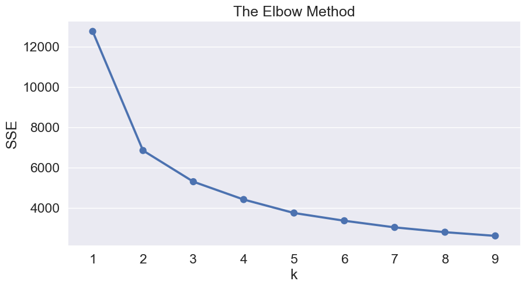

```python
# Fit KMeans and calculate SSE 'sum of squared errors' for each k
plt.figure(figsize=(10, 5))
sse = {}
for k in range(1, 10):

    # Initialize KMeans with k clusters
    kmeans = KMeans(n_clusters=k, random_state=1)

    # Fit KMeans on the normalized dataset
    kmeans.fit(data_normalized)

    # Assign sum of squared distances to k element of dictionary
    sse[k] = kmeans.inertia_
    plt.title('The Elbow Method')

# Add X-axis label "k"
plt.xlabel('k')

# Add Y-axis label "SSE"
plt.ylabel('SSE')

# Plot SSE values for each key in the dictionary

sns.pointplot(x=list(sse.keys()), y=list(sse.values()))
plt.show()
```

**intuitivly from the Elbow Method plot we can decide on having 4 clusters in Kmeans**

```python
kmeans = KMeans(n_clusters=4, random_state= 42) #randomstate 42, why? -> check Hitchhiker’s Guide to the Galaxy
kmeans.fit(data_normalized)
cluster_labels = kmeans.labels_

# Create a DataFrame by adding a new cluster label column
data_rfm_k4 = data_rfm.assign(Cluster=cluster_labels)

# Group the data by cluster
grouped = data_rfm_k4.groupby(['Cluster'])

# Calculate average RFM values and segment sizes per cluster value
grouped.agg({
    'Recency': 'mean',
    'Frequency': 'mean',
    'MonetaryValue': ['mean', 'count']
  }).round(1)
```

| Cluster | Recency mean | Frequency mean | MonetaryValue mean | MonetaryValue count |
| --- | --- | --- | --- | --- |
| 0 | 103.7 | 71.6 | 1300.7 | 1269 |
| 1 | 181.0 | 13.4 | 272.2 | 1304 |
| 2 | 13.8 | 417.6 | 8552.5 | 837 |
| 3 | 18.2 | 40.3 | 609.6 | 843 |

```python
#saving data as a Dataframe, adding the Cluster column
data_normalized = pd.DataFrame(data_normalized, index=data_rfm.index,\
                                   columns=data_rfm.columns, )
data_normalized['Cluster'] = data_rfm_k4['Cluster']
data_normalized.head()
```

| CustomerID | Recency | Frequency | MonetaryValue | Cluster |
| --- | --- | --- | --- | --- |
| 12347 | -2.149108 | 1.199653 | 1.462732 | 2 |
| 12348 | 0.382402 | -0.143475 | 0.765028 | 0 |
| 12349 | -0.576638 | 0.506434 | 0.747215 | 2 |
| 1235 | 1.373596 | -0.599354 | -0.576375 | 1 |
| 12352 | -0.130257 | 0.594655 | 0.704420 | 0 |

```python
#
data_rfm_melt = pd.melt(data_normalized.reset_index(), id_vars=['CustomerID', 'Cluster'],\
                        value_vars=['Recency', 'Frequency', 'MonetaryValue'],\
                        var_name='Attribute',value_name='Value')
data_rfm_melt.head()
```

|  | CustomerID | Cluster | Attribute | Value |
| --- | --- | --- | --- | --- |
| 0 | 12347 | 2 | Recency | -2.149108 |
| 1 | 12348 | 0 | Recency | 0.382402 |
| 2 | 12349 | 2 | Recency | -0.576638 |
| 3 | 1235 | 1 | Recency | 1.373596 |
| 4 | 12352 | 0 | Recency | -0.130257 |

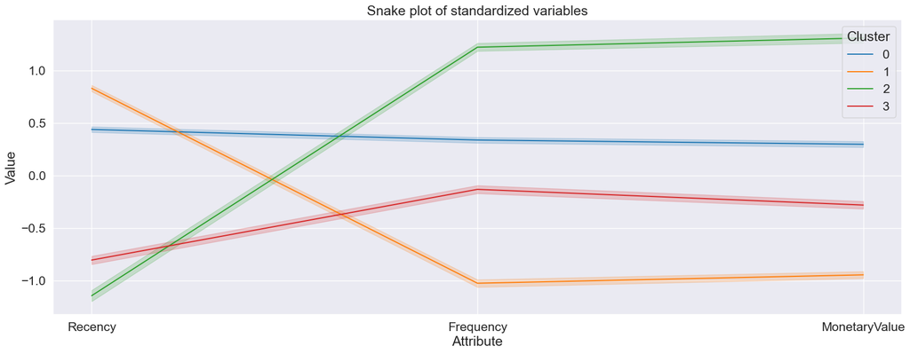

```python
plt.figure(figsize=(20,7))
plt.title('Snake plot of standardized variables')
sns.lineplot(x="Attribute", y="Value", hue='Cluster', data=data_rfm_melt,palette = 'tab10');
```

```python
data_rfm_melt = data_rfm_melt[['CustomerID','Cluster']].drop_duplicates()
df = df.merge(data_rfm_melt, how = 'inner', on = 'CustomerID')
df.head()
```

|  | CustomerID | InvoiceNo | StockCode | Description | InvoiceDate | month | day | hour | UnitPrice | Quantity | Total | Recency | Frequency | MonetaryValue | R | F | M | RFM_Segment | RFM_Score | General_Segment | Cluster |
| --- | --- | --- | --- | --- | --- | --- | --- | --- | --- | --- | --- | --- | --- | --- | --- | --- | --- | --- | --- | --- | --- |
| 0 | 1785 | 536365 | 85123A | WHITE HANGING HEART T-LIGHT HOLDER | 2018-11-29 08:26:00 | 11 | 29 | 8 | 2.55 | 6 | 15.30 | 372 | 279 | 5014.85 | 1 | 4 | 4 | 144 | 9 | 2.Platinum | 0 |
| 1 | 1785 | 536365 | 71053 | WHITE METAL LANTERN | 2018-11-29 08:26:00 | 11 | 29 | 8 | 3.39 | 6 | 20.34 | 372 | 279 | 5014.85 | 1 | 4 | 4 | 144 | 9 | 2.Platinum | 0 |
| 2 | 1785 | 536365 | 84406B | CREAM CUPID HEARTS COAT HANGER | 2018-11-29 08:26:00 | 11 | 29 | 8 | 2.75 | 8 | 22.00 | 372 | 279 | 5014.85 | 1 | 4 | 4 | 144 | 9 | 2.Platinum | 0 |
| 3 | 1785 | 536365 | 84029G | KNITTED UNION FLAG HOT WATER BOTTLE | 2018-11-29 08:26:00 | 11 | 29 | 8 | 3.39 | 6 | 20.34 | 372 | 279 | 5014.85 | 1 | 4 | 4 | 144 | 9 | 2.Platinum | 0 |
| 4 | 1785 | 536365 | 84029E | RED WOOLLY HOTTIE WHITE HEART. | 2018-11-29 08:26:00 | 11 | 29 | 8 | 3.39 | 6 | 20.34 | 372 | 279 | 5014.85 | 1 | 4 | 4 | 144 | 9 | 2.Platinum | 0 |

```python
#Relative importance per RFM
cluster_avg = data_rfm_k4.groupby(['Cluster']).mean()
population_avg = data_rfm.mean()
relative_imp = cluster_avg / (population_avg - 1)
relative_imp.round(2)
```

| Cluster | Recency | Frequency | MonetaryValue |
| --- | --- | --- | --- |
| 0 | 1.13 | 0.62 | 0.57 |
| 1 | 1.97 | 0.12 | 0.12 |
| 2 | 0.15 | 3.64 | 3.76 |
| 3 | 0.20 | 0.35 | 0.27 |

### Relative importance heatmap.

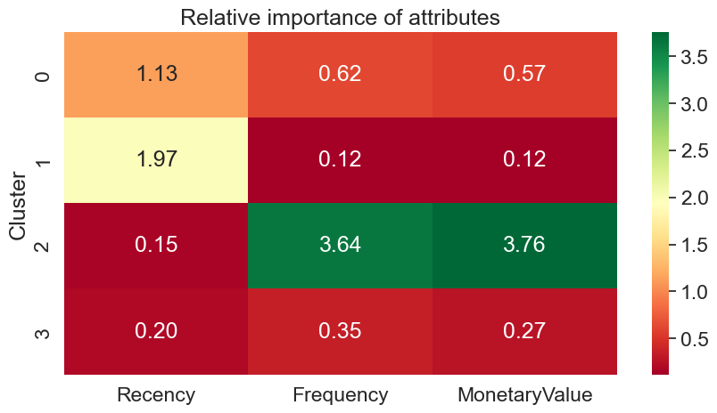

```python
# plot realtive importance of RFM features into the Kmeans clusterin
plt.figure(figsize=(10, 5))
plt.title('Relative importance of attributes')
sns.heatmap(data=relative_imp, annot=True, fmt='.2f', cmap='RdYlGn')
plt.show()
```

### Segments and Group Insight

```python
#devide customers per RFM
diamond = df[df['General_Segment']== '1.Diamond']
platinum = df[df['General_Segment']== '2.Platinum']
gold = df[df['General_Segment']== '3.Gold']
silver = df[df['General_Segment']== '4.Silver']
bronze = df[df['General_Segment']== '5.Bronze']
```

```python
#devide and rename Customer segment  as per Cluster 1 to 4 instead start with 0
cluster0 = df [ df ['Cluster'] ==0 ]
cluster1 = df [ df ['Cluster'] ==1 ]
cluster2 = df [ df ['Cluster'] ==2 ]
cluster3 = df [ df ['Cluster'] ==3 ]
```

```python
''' make a histogram subplt for total orders per day in 30 (1 month) bins  '''

def day_subviz ( data,r,c,i,label) :# r,c,i stand for row, column and index for the subplot
    plt.figure(figsize=(15,10))
    sns.set(font_scale = 1.3)
    bins = 30
    plt.subplot(r,c,i)
    data['day'].hist(bins=bins,label= label)
    plt.legend()
    plt.title(label + ' total orders per day ')
```

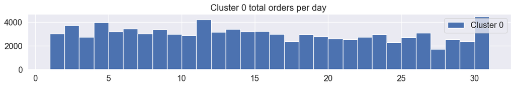

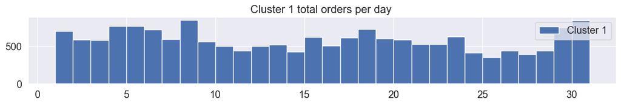

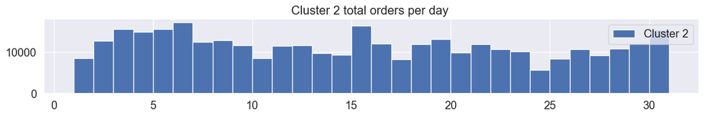

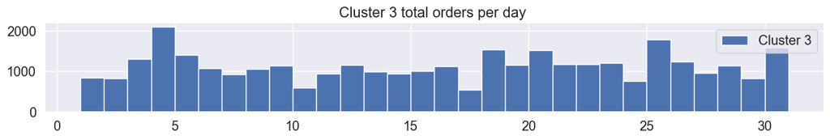

```python
# plot daily orders per Cluster
day_subviz(cluster0,5,1,1,'Cluster 0')
day_subviz(cluster1,5,1,2 ,'Cluster 1')
day_subviz(cluster2,5,1,3,'Cluster 2')
day_subviz(cluster3,5,1,4,'Cluster 3')
```

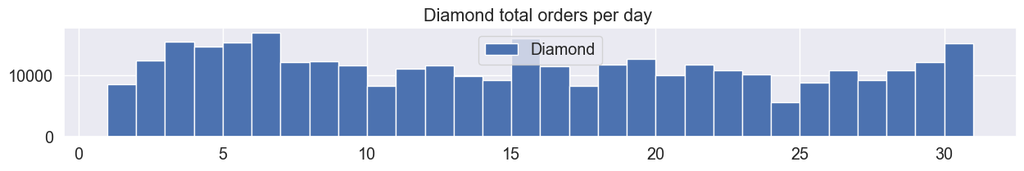

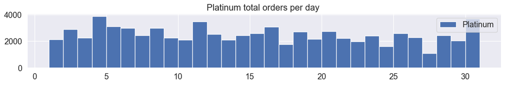

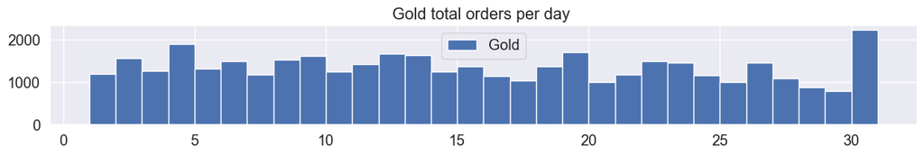

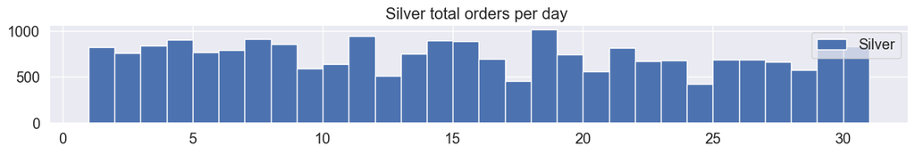

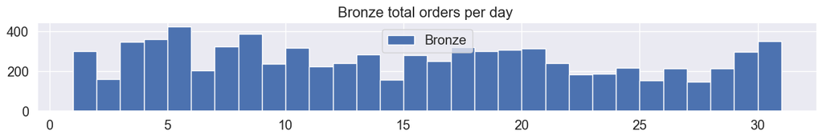

```python
# plot daily orders per Segment
day_subviz( diamond,5,1,1,'Diamond')
day_subviz( platinum,5,1,2,'Platinum')
day_subviz( gold,5,1,3,'Gold')
day_subviz( silver,5,1,4,'Silver')
day_subviz( bronze,5,1,5,'Bronze')
```

### Time Series

**Monthly and Weekly Percent Change through the whole year per Segment**

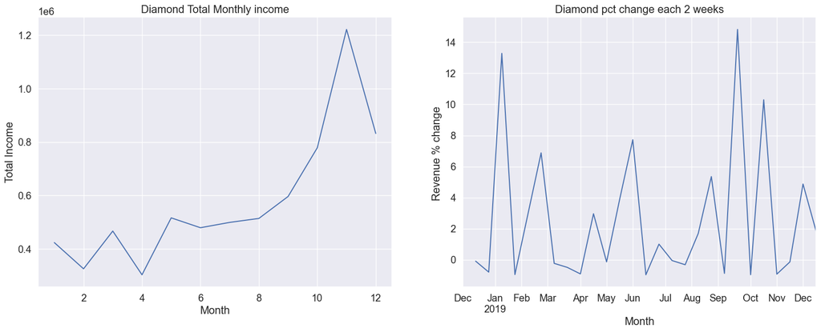

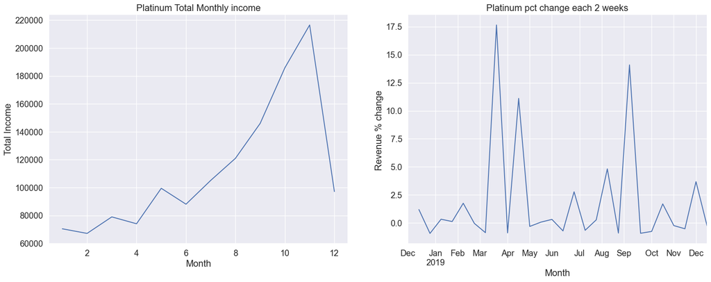

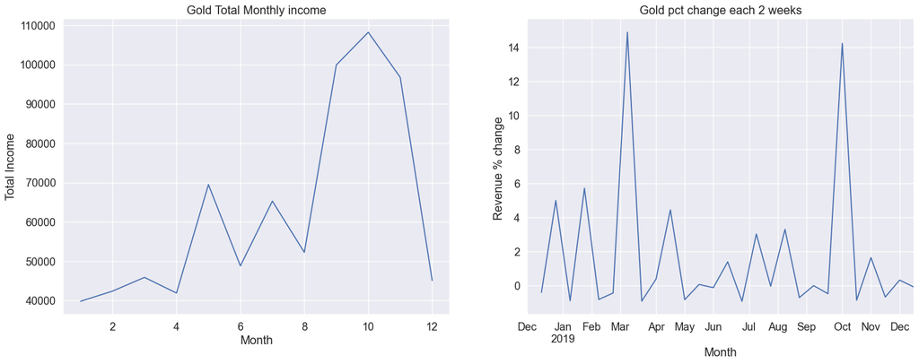

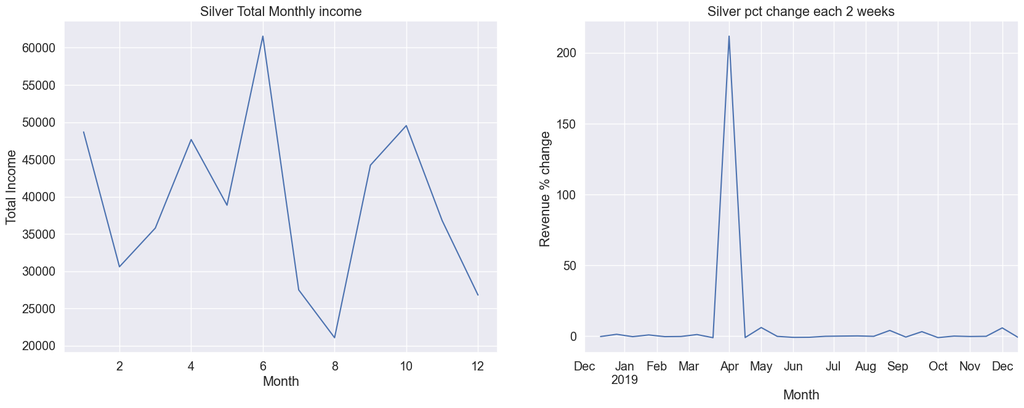

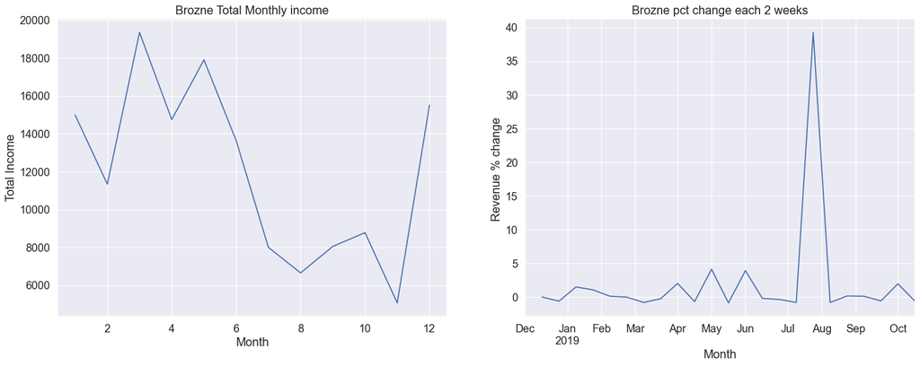

```python
# set up the funktion
def monthly_total (data, name): # data = givin data , name = its name

    ''' make subplots of the following:
    1- totaly monthly revenue for givin data
    2- total revenue pct change each 2 weeks
    '''

    plt.figure(figsize = [20,7])
    plt.subplot(1,2,1)
    sums = data.groupby(['General_Segment', 'month'])['Total'].sum().reset_index(level=0)
    for company in sums['General_Segment'].unique():
        sums[sums['General_Segment'] == company]['Total'].plot();
    plt.xlabel('Month')
    plt.ylabel('Total Income')
    plt.title(name + ' Total Monthly income')

    plt.subplot(1,2,2)
    data_day = data
    data_day = data_day.set_index('InvoiceDate')
    data_day = data_day.resample(rule = '2W').last()
    returns = data_day['Total'].pct_change()
    returns.plot()
    plt.title(name + ' pct change each 2 weeks')
    plt.ylabel('Revenue % change ')
    plt.xlabel('Month')

# plot each segment
monthly_total(diamond,'Diamond')
monthly_total(platinum,'Platinum')
monthly_total(gold,'Gold')
monthly_total(silver,'Silver')
monthly_total(bronze,'Brozne')
```

### Heatmaps & Correlations

**lets check for urchasing behavior correlations for each segment**

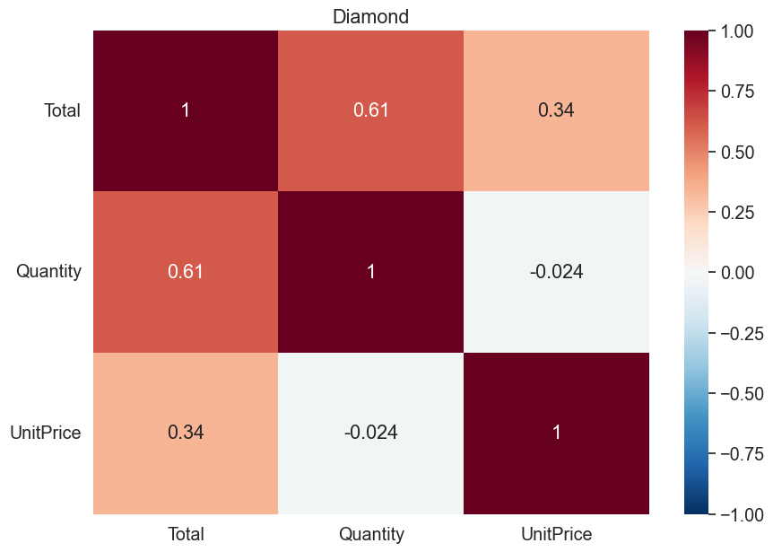

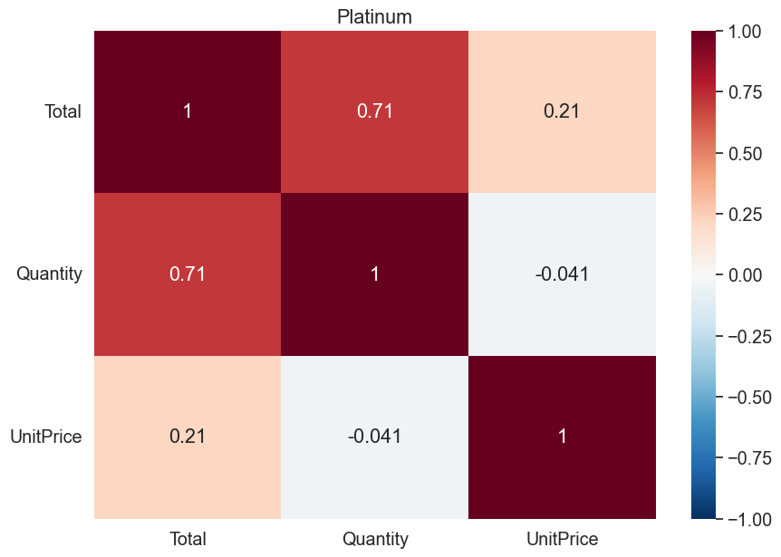

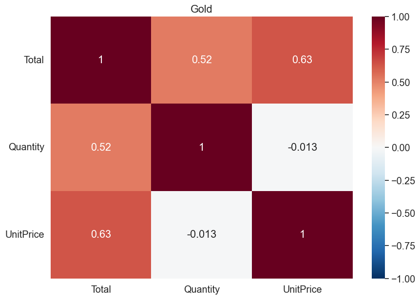

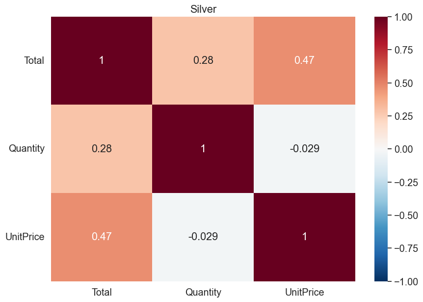

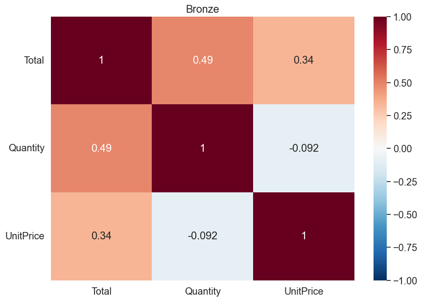

```python
def heatmap (data,name) :

    ''' plots a heatmap to show correlationS between givin values'''

    plt.figure(figsize = [10,7])
    sns.set(font_scale = 1.3)
    chart = sns.heatmap(data=data[['Total','Quantity','UnitPrice']].corr(),
           center=0, cmap='RdBu_r',annot=True, vmin= -1, vmax=1)
    chart.set_yticklabels(chart.get_yticklabels(), rotation=0 );
    plt.title(name)

heatmap(diamond,'Diamond')
heatmap(platinum,'Platinum')
heatmap(gold,'Gold')
heatmap(silver, 'Silver')
heatmap(bronze, 'Bronze')
```

**correlations shows the following purchasing behavior:**

- Diamond - above average products count in below-averag price
- Platinum - hight products count in low price
- Gold- average products count in above average price.
- Silver- low products counts in average price
- Bronze- average products count in below average price

**Gold customers buy more expensive products in average quantity , yet Platinum customers buys in larger quantities with the lowet unit price, Suggesting Platinum Customers could be another seller ?**

### Off Season Revenue

```python
def revenue_per_off_season (data):

    ''' get the percentage of Revenue from total Revenue outside peak selling season in november and December , rounded  '''

    off_season  = data.query("month != 11 & month != 12")
    per =  (off_season['Total'].sum() / data['Total'].sum())
    return per.round(2)

print ( 'Diamond',revenue_per_off_season(diamond),
' Platinum',revenue_per_off_season(platinum),
' Gold',revenue_per_off_season(gold),
' Silver',revenue_per_off_season(silver),
' Bronze',revenue_per_off_season(bronze))
#plat_off_season = platinum.query("month != 11 & month != 12 & month != 1 ")
#1 - (plat_off_season['totalsum'].sum() / platinum['totalsum'].sum())
```

```
Diamond 0.7  Platinum 0.77  Gold 0.81  Silver 0.86  Bronze 0.86
```

**must revenue comes from off season, having Bronze and silver and highest off season buyers**

### Hourly Orders per Segment

**in wich time of day our customers tend to purchase**

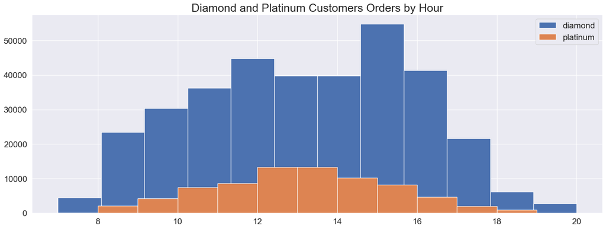

```python
# diamond and pltinum orders per hour

plt.figure(figsize=(20,7))
sns.set(font_scale = 1.5)
bins = 12
diamond['hour'].hist(bins=bins,label= 'diamond')
platinum['hour'].hist(bins=bins,label= 'platinum')
plt.title('Diamond and Platinum Customers Orders by Hour', size=22)
plt.legend()
plt.show()
```

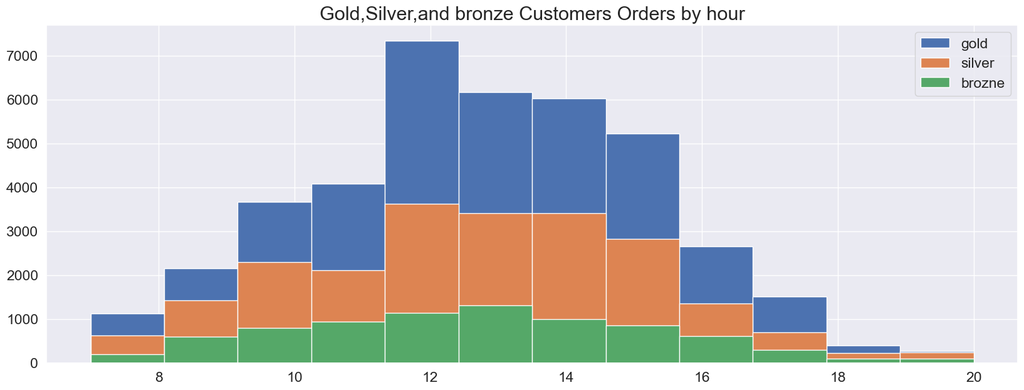

```python
# Gold, Silver adn Bronze orders per hour

plt.figure(figsize=(20,7))
sns.set(font_scale = 1.5)
gold['hour'].hist(bins=bins,label= 'gold')
silver['hour'].hist(bins=bins,label= 'silver')
bronze['hour'].hist(bins=bins,label= 'brozne')
plt.title('Gold,Silver,and bronze Customers Orders by hour', size=22)
plt.legend()
plt.show()
```

**for all our customers segments, midday seems the prominent purchasing time**

## NLP and Product Groups

### Lemmatized groups

```python
# set lemmatize funktion
def lemmatize (data):

    '''lemmatize a givin dataframe, return top 10 tokenized an lemmatized words'''

    data = data.dropna()
    wordnet_lemmatizer = WordNetLemmatizer()
    data['tokenized'] = data.apply(lambda row: nltk.word_tokenize(row['Description']), axis=1)
    our_list = data["tokenized"].tolist()
    new_list = []
    for words in our_list:
        new_list += words
    lower_tokens = [t.lower() for t in new_list]
    alpha_only = [t for t in lower_tokens if t.isalpha()]
    english_stops = set(stopwords.words('english'))
    no_stops = [t for t in alpha_only if t not in english_stops]
    lemmatized = [wordnet_lemmatizer.lemmatize(t) for t in no_stops]
    bow = Counter(lemmatized)
    return bow.most_common(10)

# Lemmatizing each segment, and general positive values data
lem_diamond = lemmatize(diamond)
lem_platinum =lemmatize(platinum)
lem_gold = lemmatize(gold)
lem_silver = lemmatize(silver)
lem_bronze = lemmatize(bronze)
lem_df = lemmatize(df)
```

```python
# defining a bar plotting funktion
def most_used_words (data, name) :

    ''' plots a barplot from a list of tuples on 1key,1value basis'''

    x = [i[0] for i in data]
    y = [i[1] for i in data]
    plt.figure(figsize = (20,3))
    plt.bar (x= x , height= y )
    plt.ylabel('items sold')
    plt.title(name + ' top sold items short description')

# plot most used words for all positive data and  per segment
most_used_words(lem_df,'all Customers')
most_used_words(lem_diamond,'Diamond Customers')
most_used_words(lem_platinum,'Platinum Customers')
most_used_words(lem_gold,'Gold Customers')
most_used_words(lem_silver,'Silver Customers')
most_used_words(lem_bronze,'Brozne Customers')
```

[output not shown]

```python
# check returns if anything special arise!
lem_df_negative = lemmatize(df_negative)
most_used_words(lem_df_negative,'returns from ')
```

[output not shown]

### Apriori Associations

```python
df_grouped= (df
          .groupby(['InvoiceNo', 'Description'])['Quantity']
          .sum().unstack().reset_index().fillna(0)
          .set_index('InvoiceNo'))
df_grouped
```

[output not shown]

```python
# encode datafram, fill  1 if found
def hot_encode(x):
    if x<= 0:
        return 0
    if x>= 1:
        return 1

# apply 1,0 if descriptiond found or not
product_sets  = df_grouped.applymap(hot_encode)
```

```python
#check data if ready
product_sets.head()
```

[output not shown]

```python
# Building the model
frq_items = apriori(product_sets, min_support = 0.03, use_colnames = True)

# Collecting the inferred rules in a dataframe
df_asso = association_rules(frq_items, metric ="lift", min_threshold = 0)
df_asso = df_asso.sort_values(['confidence', 'lift'], ascending =[False, False])
```

```python
# check top 10 associations - or above 50% Confidence
df_asso.reset_index(inplace= True, drop =True)
df_asso[df_asso['confidence'] > 0.5]
```

[output not shown]

**To construct association rules between elements or items, the algorithm considers 3 important factors which are, support, confidence and lift. Each of these factors is explained as follows:**

- **Support**: the ratio between itemX and the total number of transactions **itemX / total**
- **Confidence** the proportion of transactions with item X1, in which item X2 also appears by total of item X1 **itemX,item1X2 / X1**
- **Lift** lift is the ratio between the confidence and support : **confidenceX1X2 / Support X2**

## Hypothesis

- Christmas season revenue is higher than off season (assuming season start from 1.11 till 31.12)
- products sold in season are diffrent than out of season
- top 10 customers made 10% of Revenue

### Christmas season revenue

```python
#creat a new datafram for christmas season
df_season = df.query('month>= 11 and month <= 12')

# print and sum the total for in and out of season.
print ('Total Revenue in Christman season {}'.format(int(df_season['Total'].sum())))
print('Total Revenue off season {}'.format(int(df['Total'].sum() - df_season['Total'].sum() )))
```

[output not shown]

### products sold in season - out of season

```python
# create off season dataframe
df_off_season = df.query('month < 11')

# lemmtize dataframes
df_season_lem = lemmatize(df_season)
df_off_season_lem = lemmatize (df_off_season)
```

```python
#get the top off season products
top_sold= [i[0] for i in df_off_season_lem]
items= 0
#iterate on items lists to find similarity
for i in df_season_lem:
    if i[0] in top_sold:
        items += 1
print(f'number of same top products sold in and out of season {items}')
```

[output not shown]

### top 10 customers made 10% of Revenue

```python
# get a dataframe subset
df_total_subset = df[['CustomerID','Total']]

#group total sum by CusomterID
grouped = df_total_subset.reset_index().groupby('CustomerID',sort=False).sum()

#get top 10, exclude 1st as these are the guests
top10 = grouped.sort_values('Total', ascending=False)[1:11]
not_top10 = grouped.Total.sum() - top10.Total.sum()
#print the %
print(f'the total Percentage Revenue of the top 10 Customers is {(int((top10.Total.sum() / not_top10)*100))}%')
```

[output not shown]

## Conclusion

**insights here were taken from this Notebook and from the Ecommerce Tableau dashboard!** [see link](https://public.tableau.com/app/profile/jacob.barham/viz/EcommerceCustomers/CustomerPurchaseBehavior#2)

our customers seasonality is clearly before and around Christmas Holidays were must purchases are concluded furthermore, we also had customers into multi segments, yet all share the same product range with little to no change all year round, another metric that all segments broadly share is purchasing hours, all are normally distributed around noon.

### Suggestions

we should lunch a marketing campaign at the best value shopping times, these are at the start, mid and end of each month, and widely in the Christmas season. Make customers groups from each segment (Diamond.Cluster1, Platinum.Cluster3 …etc) then micro-manage the campaign in daily hours as given in the conclusion, for those customers who did already purchased, push Apriori association suggestions!

A/B testing for more intensive marketing times during %change peak throughout the year, as shown in the time series change.

taking into account that most products show a feminine touch, an AI model for predicting feminine behavioral customers could be built, and more feminine leaned products could be incorporated into our product pool, this could lead also to a higher revenue change for Valentin in February.

lastly, churned and negative revenue change customers should be inspected and potentially reached for a questionnaire, some changeable key findings could be laying there.

## Links

### Dashboards - Tableau

[Ecommerce Customers Segments - Time Series Dynamic](https://public.tableau.com/app/profile/jacob.barham/viz/EcommerceCustomers/CustomerPurchaseBehavior#2)

### Articles

**benificial Articles that where Handy**

1. [RFM Model with Python](https://towardsdatascience.com/recency-frequency-monetary-model-with-python-and-how-sephora-uses-it-to-optimize-their-google-d6a0707c5f17) 2.[Advanced customer segmentation](https://seifip.medium.com/starbucks-offers-advanced-customer-segmentation-with-python-737f22e245a4) 3.[Apriori Algorithm With Implementation](https://analyticsindiamag.com/beginners-guide-to-understanding-apriori-algorithm-with-implementation-in-python/) 4.[Time Series Analysis in Python](https://towardsdatascience.com/time-series-analysis-in-python-an-introduction-70d5a5b1d52a) 5.[Kmean and Elbow Method](https://towardsdatascience.com/clustering-algorithms-for-customer-segmentation-af637c6830ac)

```python
# save clean positive values csv file for outer use (Tableau)
#df.to_csv('Ecommerce_Clean', index = False)
```